# Collective Motion

Vicsek dynamics, order-disorder transitions, and agent-based rules

## Local Rules, Global Order

Collective motion is the first session where the main model is not a continuous-time ODE. The dynamics come from a repeated update rule applied to many agents at once.

## Session Arc

Base rule

Start with Vicsek alignment, noise, constant speed, and periodic boundaries.

Observable

Measure the transition with the order parameter instead of relying on animation alone.

Extensions

Then ask what changes when you add repulsion, predators, or richer decision rules.

## Why This Is Not an ODE Session

Previous sessions

State changes came from derivatives and continuous-time rate laws.

This session

Each time step updates headings and positions directly from neighbor information, so a simulation loop is more natural than `solve_ivp()`.

## Vicsek Update Rule

$$\theta_i(t + \Delta t) = \langle \theta_j(t) \rangle_{j \in \mathcal N_i} + \frac{\eta}{2} \xi_i$$

$$\mathbf x_i(t + \Delta t) = \mathbf x_i(t) + v_0 \Delta t (\cos \theta_i, \sin \theta_i)$$

At each step, every boid aligns with neighbors inside a radius $r$, adds noise, moves at constant speed, and wraps back into the box with periodic boundary conditions.

## What Moves the Transition

Noise $\eta$

Higher noise breaks alignment and pushes the system toward disorder.

Density

More local contacts make alignment easier.

Interaction radius $r$

This sets who can influence whom at each step.

Speed $v_0$

This controls how quickly local alignment propagates through the box.

## The Order Parameter Is the Summary Statistic

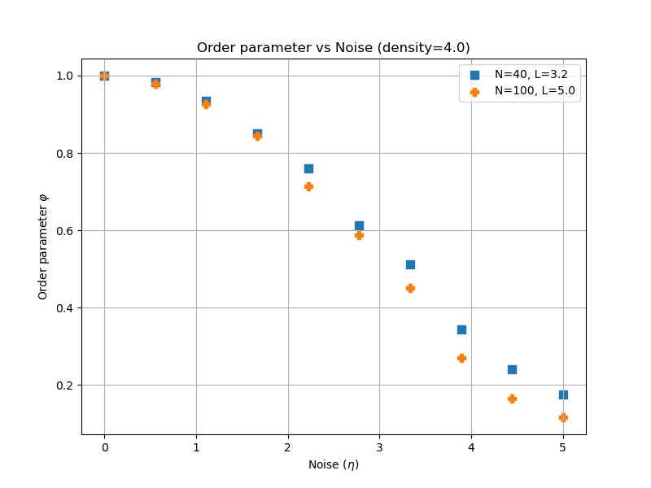

Order parameter versus noise

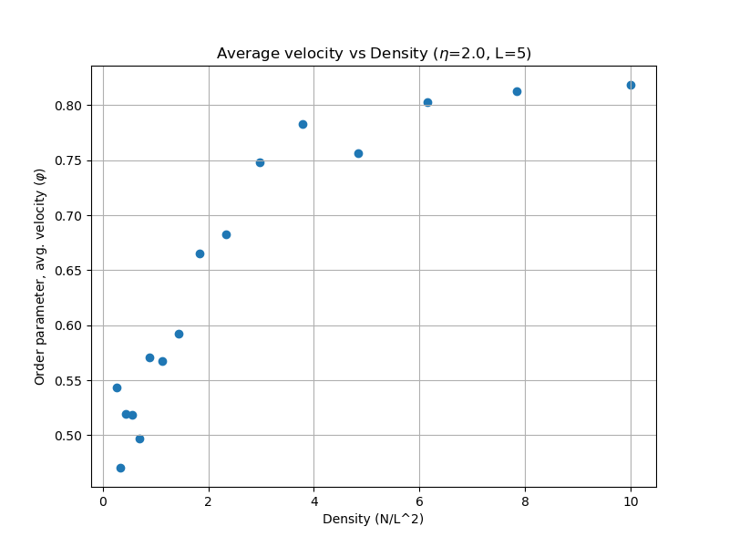

Average velocity versus density

Use the average normalized velocity to quantify how ordered the flock is. The interesting part is the transition, not just the animation.

## The Session Extends in Two Directions

Couzin model

Add a repulsion zone so agents avoid collisions instead of only aligning.

Predator extension

Add an escape rule, then decide whether the predator is passive, autonomous, or includes eating-spawning dynamics.

## Minimal Simulation Loop

```python
for step in range(num_steps):
    theta = update_angles(xy, theta, radius=r, noise=eta)
    xy = xy + speed * dt * np.vstack((np.cos(theta), np.sin(theta)))
    xy = xy % box_size
    order[step] = compute_order_parameter(theta)
```

This is the discrete-time analogue of the solver loop from the ODE sessions.

## Full Module Pages

Module overview Vicsek model Vicsek animation Vicsek validation Couzin model Predator extension Practice: Collective motion

Applied Math Lab